# Week 4 HW

## SETUP

FXN: Save graphical outputs

```r
picsave <- function(graph, name) {
  ggsave(plot = graph, filename= name, device = "pdf", width = 12, height = 8, path = "~/GitHub/S_Lipkind_Rundergrad2020/week4/pics/")
}
```

## CHAPTER 7 PROBLEMS

### 7.3.4

#### 1. Explore the distribution of each of the x, y, and z variables in diamonds. What do you learn? Think about a diamond and how you might decide which dimension is the length, width, and depth.

```r
glimpse(diamonds)
```

```
## Observations: 53,940
## Variables: 10
## $ carat   <dbl> 0.23, 0.21, 0.23, 0.29, 0.31, 0.24, 0.24, 0.26, 0.22, 0.23,...
## $ cut     <ord> Ideal, Premium, Good, Premium, Good, Very Good, Very Good, ...
## $ color   <ord> E, E, E, I, J, J, I, H, E, H, J, J, F, J, E, E, I, J, J, J,...
## $ clarity <ord> SI2, SI1, VS1, VS2, SI2, VVS2, VVS1, SI1, VS2, VS1, SI1, VS...
## $ depth   <dbl> 61.5, 59.8, 56.9, 62.4, 63.3, 62.8, 62.3, 61.9, 65.1, 59.4,...
## $ table   <dbl> 55, 61, 65, 58, 58, 57, 57, 55, 61, 61, 55, 56, 61, 54, 62,...
## $ price   <int> 326, 326, 327, 334, 335, 336, 336, 337, 337, 338, 339, 340,...
## $ x       <dbl> 3.95, 3.89, 4.05, 4.20, 4.34, 3.94, 3.95, 4.07, 3.87, 4.00,...
## $ y       <dbl> 3.98, 3.84, 4.07, 4.23, 4.35, 3.96, 3.98, 4.11, 3.78, 4.05,...
## $ z       <dbl> 2.43, 2.31, 2.31, 2.63, 2.75, 2.48, 2.47, 2.53, 2.49, 2.39,...
```

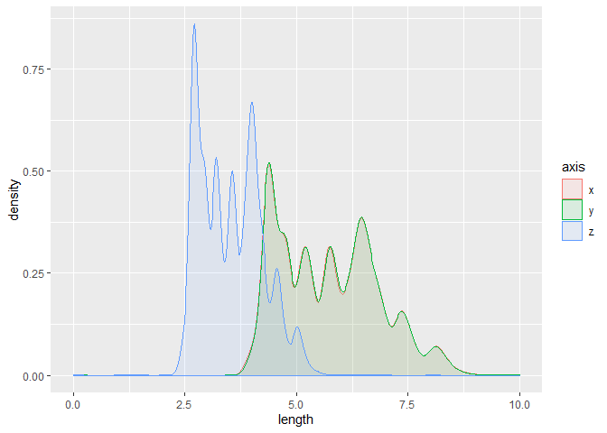

```r
#(xyz) are continuous variables, measuring the dimensions of each diamond
#Want to see distributions of each axis, but hmm, the three axes are not united by anything that I can easily call in ggplot in one go
#Solution: gathering to create "axis" and "length"

diamonds %>% gather(axis, length, c(x,y,z)) %>%
  ggplot(aes(x = length, fill = axis, color = axis)) +
  geom_density(alpha = .1) +
  xlim(0,10)
```

```r
#x and y axes have nearly complete overlap, while z is smaller. Is z depth?
```

#### 2. Explore the distribution of price. Do you discover anything unusual or surprising? (Hint: Carefully think about the binwidth and make sure you try a wide range of values.)

```r
glimpse(diamonds)
```

```
## Observations: 53,940
## Variables: 10
## $ carat   <dbl> 0.23, 0.21, 0.23, 0.29, 0.31, 0.24, 0.24, 0.26, 0.22, 0.23,...
## $ cut     <ord> Ideal, Premium, Good, Premium, Good, Very Good, Very Good, ...
## $ color   <ord> E, E, E, I, J, J, I, H, E, H, J, J, F, J, E, E, I, J, J, J,...
## $ clarity <ord> SI2, SI1, VS1, VS2, SI2, VVS2, VVS1, SI1, VS2, VS1, SI1, VS...
## $ depth   <dbl> 61.5, 59.8, 56.9, 62.4, 63.3, 62.8, 62.3, 61.9, 65.1, 59.4,...
## $ table   <dbl> 55, 61, 65, 58, 58, 57, 57, 55, 61, 61, 55, 56, 61, 54, 62,...
## $ price   <int> 326, 326, 327, 334, 335, 336, 336, 337, 337, 338, 339, 340,...
## $ x       <dbl> 3.95, 3.89, 4.05, 4.20, 4.34, 3.94, 3.95, 4.07, 3.87, 4.00,...
## $ y       <dbl> 3.98, 3.84, 4.07, 4.23, 4.35, 3.96, 3.98, 4.11, 3.78, 4.05,...
## $ z       <dbl> 2.43, 2.31, 2.31, 2.63, 2.75, 2.48, 2.47, 2.53, 2.49, 2.39,...
```

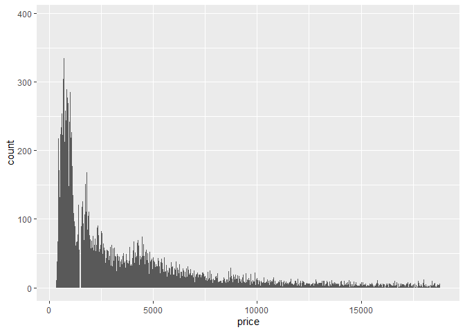

```r
(b10 <- diamonds %>% ggplot(aes(
  x = price)) +
  geom_histogram(binwidth = 10))
```

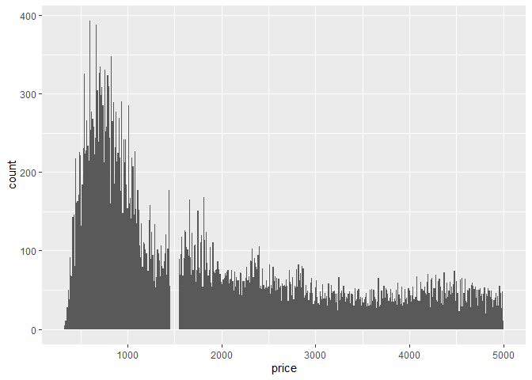

```r
#Appears to be a small gap in rows that have a price ~$1000

(psmallb10 <- diamonds %>% filter(price < 5000) %>%
  ggplot(aes(x = price)) +
  geom_histogram(binwidth = 10))
```

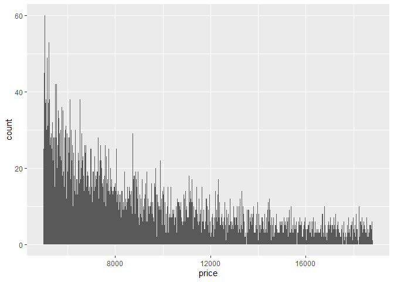

```r
#More accurately, the gap is around $1500

(plargeb10 <- diamonds %>% filter(price > 5000) %>%
  ggplot(aes(x = price)) +
  geom_histogram(binwidth = 10))
```

```r
#seems pretty standard, makes sense to have lower counts overall
```

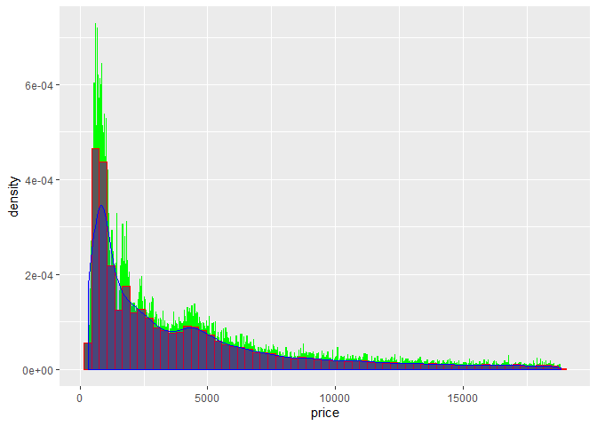

```r
#for funsies, comparing binwidth 10 to a density plot, which doesn't use bins at all
diamonds %>% ggplot(aes(
  x = price)) +
  geom_histogram(aes(y = ..density..), binwidth = 10, position = "identity", color = "green") +
  geom_histogram(aes(y = ..density..), binwidth = 300, position = "identity", color = "red") +
  geom_density(fill = "blue", alpha = .2, color = "blue")
```

```r
#The density plot itself acts like a smoothened histogram plot, generalizing the peaks and valleys seen in binwidth = 10 (green)
#Not sure why the density plot underestimates the beginning peak so much
# I'm sorry this looks so ugly.
```

#### 3. How many diamonds are 0.99 carat? How many are 1 carat? What do you think is the cause of the difference?

```r
diamonds %>% count(carat == .99) #23
```

```
## # A tibble: 2 x 2
##   `carat == 0.99`     n
##   <lgl>           <int>
## 1 FALSE           53917
## 2 TRUE               23
```

```r
diamonds %>% count(carat == 1.0) #1558
```

```
## # A tibble: 2 x 2
##   `carat == 1`     n
##   <lgl>        <int>
## 1 FALSE        52382
## 2 TRUE          1558
```

```r
#Hypothesis: it is likely that human measurers were likely to round to the nearest integer, rather than specifying .99.
```

#### 4. Compare and contrast coord_cartesian() vs xlim() or ylim() when zooming in on a histogram. What happens if you leave binwidth unset? What happens if you try and zoom so only half a bar shows?

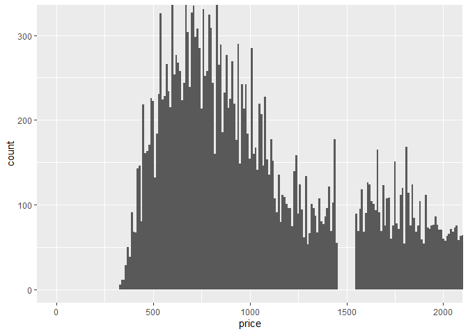

```r
a <- diamonds %>% ggplot(aes(
  x = price)) +
  geom_histogram(binwidth = 10) +
  coord_cartesian(xlim = c(0,2000), ylim = c(0, 320))

b <- diamonds %>% ggplot(aes(
  x = price)) +
  geom_histogram(binwidth = 10) +
  xlim(0,2000) +
  ylim(0,320) #xlim and ylim removed far more values

c <- diamonds %>% ggplot(aes(
  x = price)) +
  geom_histogram() +
  coord_cartesian(xlim = c(0,2000), ylim = c(0, 320)) #defaults to binwidth = 30

d <- diamonds %>% ggplot(aes(
  x = price)) +
  geom_histogram(binwidth = 200) +
  coord_cartesian(xlim = c(0,100)) #nothing shows up when the range is smaller than the size of the bin

a
```

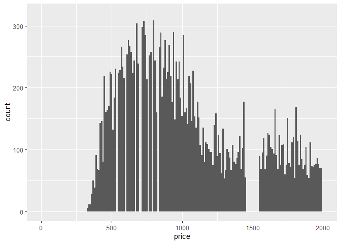

```r
b
```

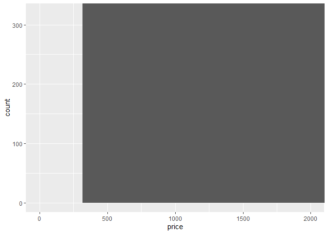

```r
c
```

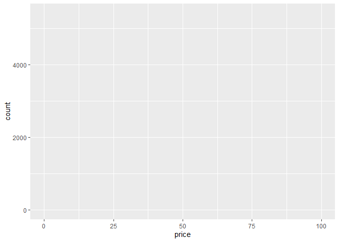

```r
d
```